# lab4_hiv_matching_sequence_to_patient_solutions

## Are sequences from the same patient alike?

```python
from datascience import *
%matplotlib inline
import matplotlib.pyplot as plots
import numpy as np
plots.style.use('fivethirtyeight')
```

## Import the data

Our data will come from [LANL HIV database](http://www.hiv.lanl.gov). This time, we use the intra-patient search to find sequences that come from the same patient. The data we use today come from a study by Archary et al. The dataset contains env sequences from four different patients. The patient identifier of four of the sequences has been replaced with 'X1', 'X2', 'X3', and 'X4'.

Your task is to see if you can identify which patient each of these mystery sequences came from.

First, load the data. This time, we'll be able to achieve all our goals with the data in table format:

```python
intrapatient_seqs=Table.read_table(
    'https://github.com/shishiluo/Genomics-DataScience/raw/master/data/hiv_intrapatient_lanl_db_trimmed_mystery.csv')
```

**Q1**: Answering the following will give us a sense of the dataset:  
(a) What are the IDs of the four patients?  
(b) How many sequences per patient?  
(c) Check that the sequences are aligned.

```python
intrapatient_seqs.group('Patient_ID')
```

| Patient_ID | count |
| --- | --- |
| SK010 | 21 |
| SK035 | 21 |
| SK169 | 19 |
| SK200 | 19 |
| X1 | 1 |
| X2 | 1 |
| X3 | 1 |
| X4 | 1 |

```python
#checking that all sequences are aligned

len_seq = []
for seq in intrapatient_seqs.column(1):
    len_seq += [len(seq)]

set(len_seq)
```

```
{2823}
```

## Distances between sequences

Let us assume that sequences from the same patient are more similar than sequences from different patients. Then, to identify which patients the mystery sequences are from, we need a way to measure the distance between sequences.

One approach is to use **Hamming Distance**. The Hamming Distance between two strings (of equal length) is the number of positions where the strings differ.

For example, 'Hello, Dolly!' and 'Help-, Dolly!' have Hamming Distance 2.

The function below outputs the Hamming Distance between two strings.

```python
def hammingDistance(s1, s2):
    '''For two strings s1 and s2, output the number of position that they differ in.
    Strings s1 and s2 must be the same length.'''
    if len(s1)!=len(s2):
        return('The input strings are not of the same length.')
    else:
        return(sum([i!=j for i,j in zip(s1, s2)]))
```

**Q2**: Check that this function indeed does what it's supposed to do. In addition to a typical usage case, you should test the case where the two strings are identical and also the case where the two strings have different lengths.

```python
hammingDistance('abcde', 'Abcde')
```

```
1
```

```python
hammingDistance('abcde', 'abcde')
```

```
0
```

```python
hammingDistance('string', 'longerstring')
```

```
'The input strings are not of the same length.'
```

## Identifying the mystery sequences

Armed with the `hammingDistance()` we can try to identify which patients each mystery sequence came from. And we can even exclusively use built-in Table functions (if that's what you prefer).

**Q3**: Identify which patient has the HIV sequence that is most similar to sequence X1.

**Q4**: Generalize the code you use in **Q3** to a function that takes in X1, X2, etc and outputs the most likely patient

```python
# Creating a function that takes as input an unknown individual and returns the Patient ID
# to whom the sequence most likely belongs to

def whose_is_it(x):
    x_sequence = intrapatient_seqs.where(intrapatient_seqs.column(0), x).column(1).item(0)
    hdist_x = []
    for seq in intrapatient_seqs.column(1):
        hdist_x += [hammingDistance(seq, x_sequence)]
    patient_id_x = intrapatient_seqs.with_column('Hamming Distance', hdist_x).sort(2).column(0).item(1)
    print('Sequence', x, 'most likely belongs to the individual with patient ID', patient_id_x)
```

```python
for unknown in ['X1', 'X2', 'X3', 'X4']:
    whose_is_it(unknown)
```

```
Sequence X1 most likely belongs to the individual with patient ID SK200
Sequence X2 most likely belongs to the individual with patient ID SK035
Sequence X3 most likely belongs to the individual with patient ID SK010
Sequence X4 most likely belongs to the individual with patient ID SK169
```

**Q5**: What are some further analyses or visualizations you can carry out to support your conclusions?

```python
# check that indeed all of the SK200 sequences are closer to X1, etc for X2, X3, X4
def plot_distances(x):
    x_sequence = intrapatient_seqs.where(intrapatient_seqs.column(0), x).column(1).item(0)
    hdist_x = []
    for seq in intrapatient_seqs.column(1):
        hdist_x += [hammingDistance(seq, x_sequence)]
    patient_id_x = intrapatient_seqs.with_column('Hamming Distance', hdist_x)
    # exclude mystery sequences rows (which are the last 4)
    patient_id_x.exclude([80,81,82,83]).pivot_hist('Patient_ID', 'Hamming Distance')
```

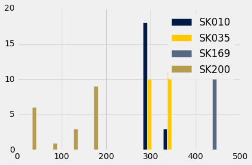

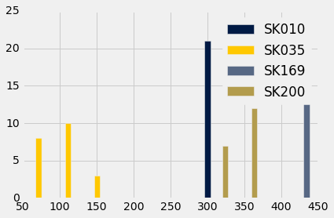

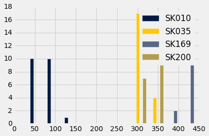

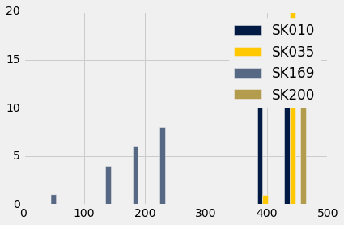

```python
for unknown in ['X1', 'X2', 'X3', 'X4']:
    plot_distances(unknown)
```

Note that SK200 sequences are all closest to X1, SK035 are all closest to X2, SK010 are all closest to X3, and SK169 are all closest to X4.

## Analyzing this dataset further (optional)

**Q6**: What is the average Hamming distance between pairs of sequences obtained from the same patient? Does this vary from patient to patient in this data set?

**Q7**: Using code from the previous lab, plot the variation in the sequences position by position for each patient. Are the patterns of variation consistent between patients?